# [Заметки по R](http://bdemeshev.github.io/r_cycle/): R внутри документов

04.01.2016

```r
library("knitr")
library("dplyr")
```

С помощью R удобно создавать и документы предназначенные для чтения человеком. Теоретически, любой язык разметки документов можно комбинировать с командами R. Мы остановимся на двух наиболее актуальных для написания статей и презентаций: латехе и маркдауне.

Маркдаун — очень простой язык разметки, и поэтому он легко автоматически конвертируется в более сложные форматы: `html`, `tex`, `docx` и другие.

## Цепочка Rmd-md-html

Начнём с создания `Rmd` документа, который будет автоматически преобразовываться в `html`.

Минимальный пример, `26_small_rmd_demo.Rmd`:

````
---
title: "Сопелка"
author: "Винни-Пух"
date: "1969"
lang: russian
output: html_document
---

В этой Сопелке Винни-Пух узнает, сколько будет 2 умножить 2:
```{r}
a <- 2
b <- 2
a * b
```
````

```r
library("htmlwidgets") # работа с виджетами
library("DiagrammeR") # рисование диаграмм
library("webshot") # сохранение виджетов в формате png или pdf
```

Для динамических интерактивных документов формат `html` *гораздо* лучше, чем `docx` или `pdf`. Помимо статичных графиков и таблиц здесь уйма возможностей!!! Их можно и нужно использовать в презентациях!

Интерактивная карта:

```r
library("leaflet")
map <- leaflet() %>%
  addTiles() %>%  # Add default OpenStreetMap map tiles
  addMarkers(lng = 37.6087, lat = 55.72069,
             popup = "Особняк Симоно")
map
```

[interactive chart not shown]

Временной ряд с масштабированием:

```r
library("dygraphs")
dygraph(nhtemp, main = "New Haven Temperatures") %>%
  dyRangeSelector(dateWindow = c("1920-01-01", "1960-01-01"))
```

[interactive chart not shown]

Гистограмма с переключением:

```r
library("rCharts")
hair_eye_male <- filter(as.data.frame(HairEyeColor), Sex == "Male")
a <- nPlot(Freq ~ Hair, group = 'Eye', data = hair_eye_male, type = 'multiBarChart')
a$show("iframesrc", cdn = TRUE)
```

[interactive chart not shown]

Если `hmtl`-виджет очень понравился, то его можно и в статический документ экспортировать.

Виджет, чтобы экспортировать виджеты, называется exportwidget.

[figure not shown]

Автоматическое сохранение виджетов в png/pdf также возможно, например, с помощью пакета `webshot`. Для использования `webshot` потребуется установить [`phantomjs`](http://phantomjs.org/) и добавить путь в переменную `PATH`. На маке есть маленький баг в `phantomjs` и есть [исправление для него](https://github.com/eugene1g/phantomjs/releases). Проверить, что R видит `phantomjs` можно командой `Sys.which("phantomjs")`. В ответ R должен выдать путь к установленному исполняемому файлу `phantomjs`.

```r
m <- grViz(" digraph { a->b; b->c; c->a; }")
saveWidget(m, "temp.html", selfcontained = FALSE)
webshot("temp.html", file = "temp.png", cliprect = "viewport")
```

И покажем сохранённую картинку:

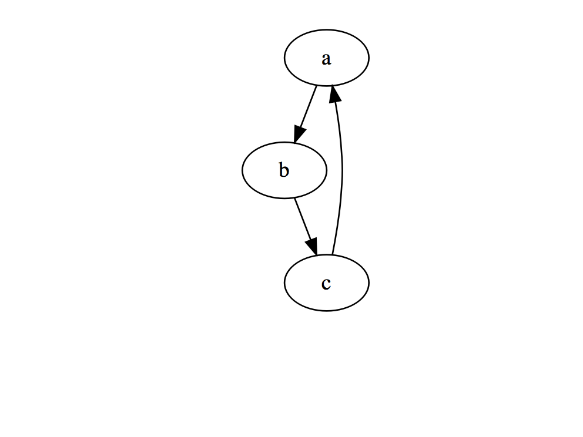

## Цепочка Rmd-md-tex-pdf

Цепочка Rmd-md-tex-pdf длиннее, чем Rnw-tex-pdf. Минус в том, что выше риск столкнуться с проблемой при преобразованиях на пути к финальному `pdf`. Плюс в большей универсальности: захотел вместо `pdf` сделать `html` и через несколько секунд всё готово, а сделать `html` из `Rnw` нетривиальная задача.

Подгрузка пакетов и прочее в начале документа:

- отдельные строки
- целый файл

#### Список литературы

Почиташки:

- [R-markdown](http://rmarkdown.rstudio.com/)
- [Шпаргалка по R-markdown](https://www.rstudio.com/resources/cheatsheets/) от R-studio
- Yihui, [knitr](http://yihui.name/knitr/)
- Подборка [htmlwidgets](http://www.htmlwidgets.org/)
- Hafen, [htmlwidgets-gallery](http://hafen.github.io/htmlwidgetsgallery/)
- [Rcharts gallery](http://rcharts.io/gallery/)